# Project_PracticalMachineLearning

Maja Kocic

12 november 2016

## Goal

The goal of your project is to predict the manner in which they did the exercise. This is the “classe” variable in the training set. You may use any of the other variables to predict with. You should create a report describing how you built your model, how you used cross validation, what you think the expected out of sample error is, and why you made the choices you did. You will also use your prediction model to predict 20 different test cases.

## Background

Using devices such as JawboneUp, NikeFuelBand, and Fitbitit is now possible to collect a large amount of data about personal activity relatively inexpensively. These type of devices are part of the quantified self movement - a group of enthusiasts who take measurements about themselves regularly to improve their health, to find patterns in their behavior, or because they are tech geeks. One thing that people regularly do is quantify how much of a particular activity they do, but they rarely quantify how well they do it.

In this project, the goal is to use data from accelerometers on the belt, forearm, arm, and dumbell of 6 participants. They were asked to perform barbell lifts correctly and incorrectly in 5 different ways. More information is available from the website: http://groupware.les.inf.puc-rio.br/har (see the section on the Weight Lifting Exercise Dataset).

### Preparing the data and R packages

### Getting Data

The raw training data has 19622 rows of observations and 158 features (predictors). Column X is unusable row number. While the testing data has 20 rows and the same 158 features. There is one column of target outcome named classe. ###Load data Remove near zero covariates and those with more than 80% missing values since these variables will not provide much power for prediction. Calculate correlations between each remaining feature to the response, classe. Use spearman rank based correlation because classe is a factor. Plot the two features that have highest correlation with classe and color with classe to see if we can separate response based on these features.

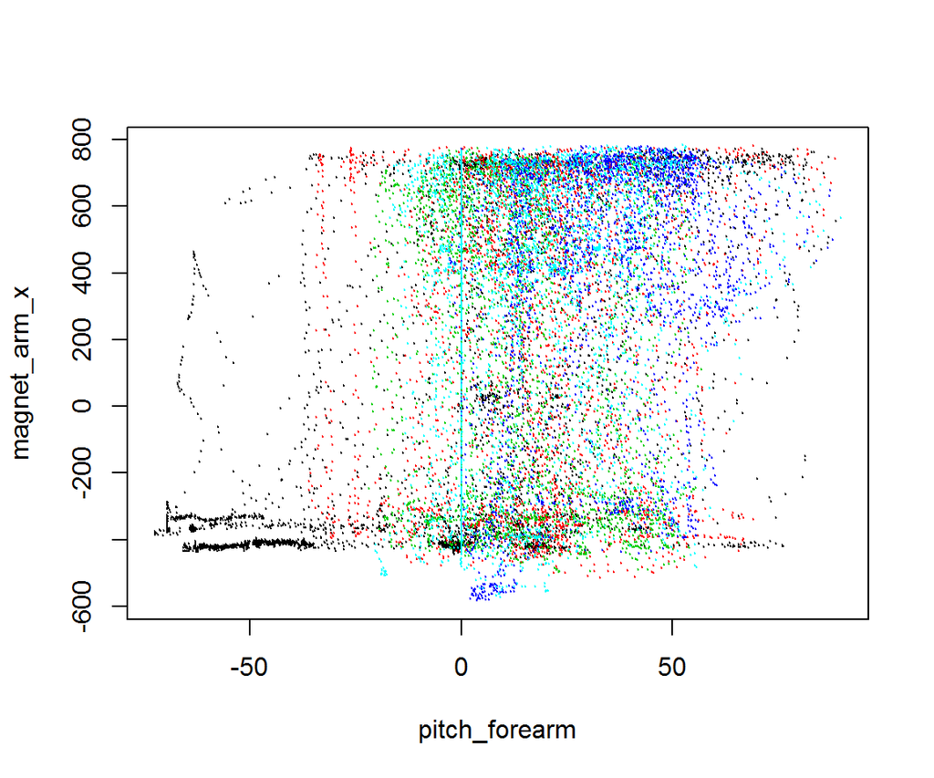

```r
# plot predictors
#summary(cor)
plot(training[, names(which.max(cor))], training[, names(which.max(cor[-which.max(cor)]))], col = training$classe, pch = 19, cex = 0.1, xlab = names(which.max(cor)), ylab = names(which.max(cor[-which.max(cor)])))
```

There doesn’t seem to be any strong predictors that correlates with classe well, so linear regression model is probably not suitable in this case. Boosting and random forests algorithms may generate more robust predictions for our data.

### Boosting model

Fit model with boosting algorithm and 10-fold cross validation to predict classe with all other predictors. Plot accuracy of this model on the scale [0.9, 1].

```
Loading required package: plyr
```

```r
boostFit
```

```
## Stochastic Gradient Boosting
##
## 19622 samples
##    57 predictor
##     5 classes: 'A', 'B', 'C', 'D', 'E'
##
## No pre-processing
## Resampling: Cross-Validated (10 fold)
## Summary of sample sizes: 17660, 17661, 17659, 17660, 17658, 17660, ...
## Resampling results across tuning parameters:
##
##   interaction.depth  n.trees  Accuracy   Kappa
##   1                   50      0.8393639  0.7961134
##   1                  100      0.8996033  0.8728506
##   1                  150      0.9268174  0.9072902
##   2                   50      0.9583122  0.9472298
##   2                  100      0.9870552  0.9836261
##   2                  150      0.9923558  0.9903314
##   3                   50      0.9847618  0.9807247
##   3                  100      0.9941905  0.9926519
##   3                  150      0.9972481  0.9965193
##
## Tuning parameter 'shrinkage' was held constant at a value of 0.1
##
## Tuning parameter 'n.minobsinnode' was held constant at a value of 10
## Accuracy was used to select the optimal model using  the largest value.
## The final values used for the model were n.trees = 150,
##  interaction.depth = 3, shrinkage = 0.1 and n.minobsinnode = 10.
```

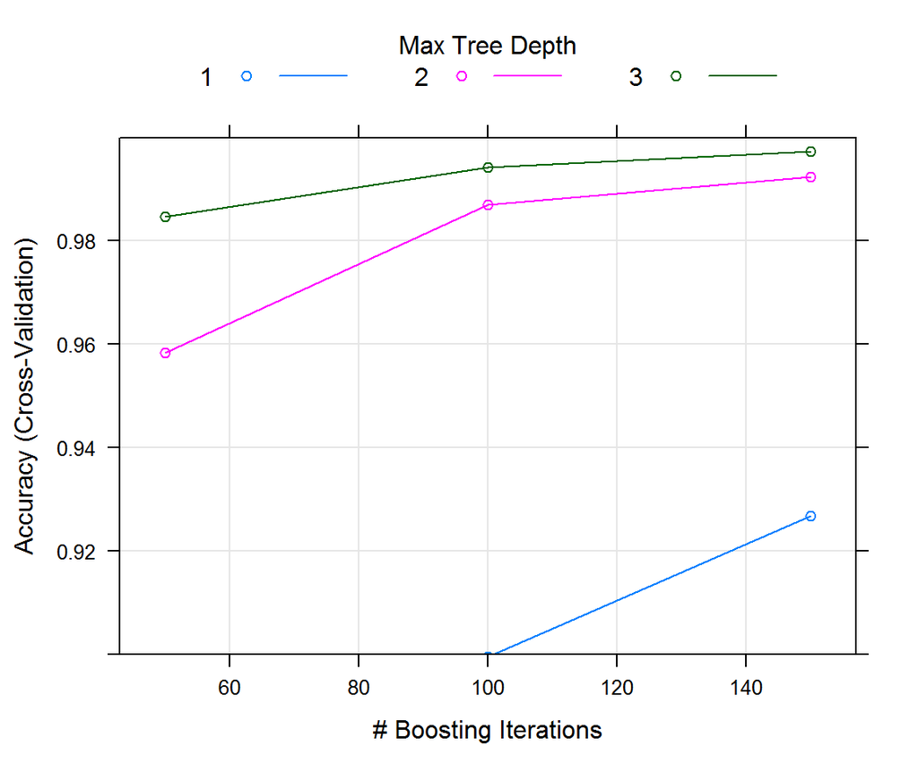

```r
plot(boostFit, ylim = c(0.9, 1))
```

The boosting algorithm generated a good model with accuracy = 0.997.

### Random forests model

Fit model with random forests algorithm and 10-fold cross validation to predict classe with all other predictors. Plot accuracy of the model on the same scale as boosting model.

```r
rfFit
```

```
## Random Forest
##
## 19622 samples
##    57 predictor
##     5 classes: 'A', 'B', 'C', 'D', 'E'
##
## No pre-processing
## Resampling: Cross-Validated (10 fold)
## Summary of sample sizes: 17660, 17661, 17659, 17660, 17658, 17660, ...
## Resampling results across tuning parameters:
##
##   mtry  Accuracy   Kappa
##    2    0.9915403  0.9892980
##   40    0.9994904  0.9993554
##   79    0.9992865  0.9990975
##
## Accuracy was used to select the optimal model using  the largest value.
## The final value used for the model was mtry = 40.
```

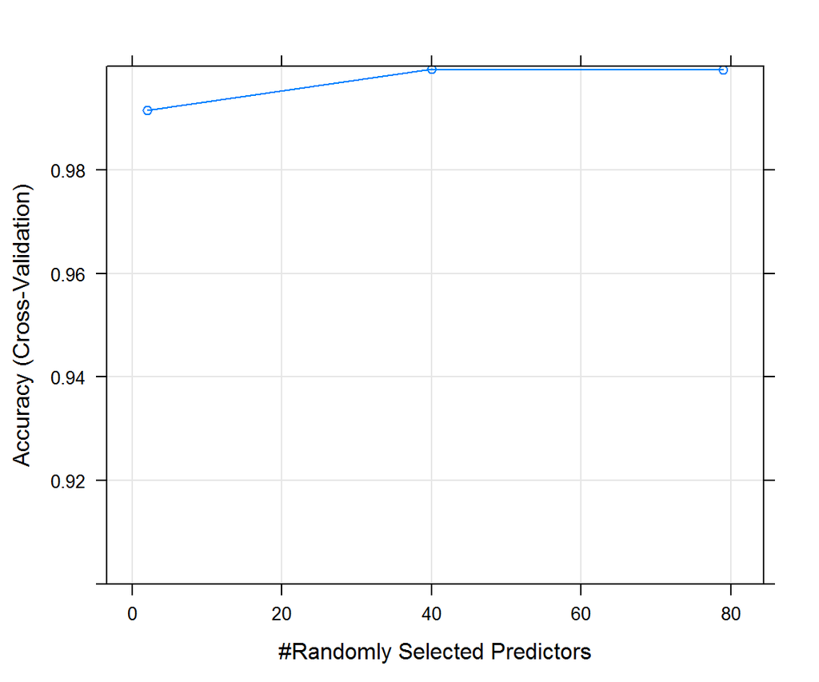

```r
plot(rfFit, ylim = c(0.9, 1))
```

```r
imp <- varImp(rfFit)$importance
imp$max <- apply(imp, 1, max)
imp <- imp[order(imp$max, decreasing = T), ]
```

The random forests algorithm generated a very accurate model with accuracy close to 1. Compared to boosting model, this model generally has better performance in terms of accuracy as we see from the plots.

### Final model and prediction

```
##
## Call:
##  randomForest(x = x, y = y, mtry = param$mtry, importance = ..1)
##                Type of random forest: classification
##                      Number of trees: 500
## No. of variables tried at each split: 40
##
##         OOB estimate of  error rate: 0.04%
## Confusion matrix:
##      A    B    C    D    E  class.error
## A 5580    0    0    0    0 0.0000000000
## B    2 3795    0    0    0 0.0005267316
## C    0    3 3419    0    0 0.0008766803
## D    0    0    1 3214    1 0.0006218905
## E    0    0    0    1 3606 0.0002772387
```

```
##  [1] "B" "A" "B" "A" "A" "E" "D" "B" "A" "A" "B" "C" "B" "A" "E" "E" "A"
## [18] "B" "B" "B"
```